# STA138_Project

Grant Smith

11/26/2019

**Data**

```r
Byn<-read.csv('Byssinosis.csv')
Byn$Workspace<-as.factor(Byn$Workspace)
(Byn)
```

```
##    Employment Smoking Sex Race Workspace Byssinosis Non.Byssinosis
## 1         <10     Yes   M    W         1          3             37
## 2         <10     Yes   M    O         1         25            139
## 3         <10     Yes   F    W         1          0              5
## 4         <10     Yes   F    O         1          2             22
## 5         <10      No   M    W         1          0             16
## 6         <10      No   M    O         1          6             75
## 7         <10      No   F    W         1          0              4
## 8         <10      No   F    O         1          1             24
## 9       10-19     Yes   M    W         1          8             21
## 10      10-19     Yes   M    O         1          8             30
## 11      10-19     Yes   F    W         1          0              0
## 12      10-19     Yes   F    O         1          0              0
## 13      10-19      No   M    W         1          2              8
## 14      10-19      No   M    O         1          1              9
```

[output cut: 58 more lines]

```r
#sum(Byn$Byssinosis,Byn$Non.Byssinosis) 5419

#Summary Stats
sum(Byn$Byssinosis[Byn$Smoking=='Yes'],Byn$Non.Byssinosis[Byn$Smoking=='Yes'])
```

```
## [1] 3189
```

```r
sum(Byn$Byssinosis[Byn$Smoking=='No'],Byn$Non.Byssinosis[Byn$Smoking=='No'])
```

```
## [1] 2230
```

```r
sum(Byn$Byssinosis[Byn$Smoking=='Yes'],Byn$Non.Byssinosis[Byn$Smoking=='Yes'])
```

```
## [1] 3189
```

```r
sum(Byn$Byssinosis[Byn$Smoking=='No'],Byn$Non.Byssinosis[Byn$Smoking=='No'])
```

```
## [1] 2230
```

```r
sum(Byn$Byssinosis[Byn$Sex=='M'],Byn$Non.Byssinosis[Byn$Sex=='M'])
```

```
## [1] 2916
```

```r
sum(Byn$Byssinosis[Byn$Sex=='F'],Byn$Non.Byssinosis[Byn$Sex=='F'])
```

```
## [1] 2503
```

```r
sum(Byn$Byssinosis[Byn$Employment=='<10'],Byn$Non.Byssinosis[Byn$Employment=='<10'])
```

```
## [1] 2729
```

```r
sum(Byn$Byssinosis[Byn$Employment=='10-19'],Byn$Non.Byssinosis[Byn$Employment=='10-19'])
```

```
## [1] 712
```

```r
sum(Byn$Byssinosis[Byn$Employment=='>=20'],Byn$Non.Byssinosis[Byn$Employment=='>=20'])
```

```
## [1] 1978
```

```r
sum(Byn$Byssinosis[Byn$Workspace==1],Byn$Non.Byssinosis[Byn$Workspace==1])
```

```
## [1] 669
```

```r
sum(Byn$Byssinosis[Byn$Workspace==2],Byn$Non.Byssinosis[Byn$Workspace==2])
```

```
## [1] 1300
```

```r
sum(Byn$Byssinosis[Byn$Workspace==3],Byn$Non.Byssinosis[Byn$Workspace==3])
```

```
## [1] 3450
```

**Initial Observations**

-workspace,employment is ordinal -smoking,sex,race binary

-165 cases of bysinosis -5254 non-bysinosis

Since our data is categorical we are not able to use traditional methods such as linear regression. As such the first method we will attemtp to use to analyze the data is logistic regression.

```r
n<-165+5254

full.gl<-glm(cbind(Byssinosis,Non.Byssinosis)~Employment + Smoking+Sex+Race +Workspace ,family=binomial(link=logit),data=Byn)
summary(full.gl)
```

```
##
## Call:
## glm(formula = cbind(Byssinosis, Non.Byssinosis) ~ Employment +
##     Smoking + Sex + Race + Workspace, family = binomial(link = logit),
##     data = Byn)
##
## Deviance Residuals:
##     Min       1Q   Median       3Q      Max
## -1.5240  -0.8105  -0.1952   0.2071   1.5643
##
## Coefficients:
##                 Estimate Std. Error z value Pr(>|z|)
## (Intercept)      -2.3463     0.2639  -8.891  < 2e-16 ***
## Employment>=20    0.7531     0.2161   3.484 0.000493 ***
## Employment10-19   0.5641     0.2617   2.156 0.031091 *
## SmokingYes        0.6413     0.1944   3.299 0.000971 ***
## SexM             -0.1239     0.2288  -0.542 0.587983
## RaceW            -0.1163     0.2072  -0.562 0.574426
## Workspace2       -2.5799     0.2921  -8.834  < 2e-16 ***
## Workspace3       -2.7306     0.2153 -12.681  < 2e-16 ***
## ---
## Signif. codes:  0 '***' 0.001 '**' 0.01 '*' 0.05 '.' 0.1 ' ' 1
##
## (Dispersion parameter for binomial family taken to be 1)
##
##     Null deviance: 322.527  on 64  degrees of freedom
## Residual deviance:  43.271  on 57  degrees of freedom
## AIC: 165.95
##
## Number of Fisher Scoring iterations: 5
```

## Assumptions

```r
library(car)
vif(full.gl) #no multicollinearity
```

```
##                GVIF Df GVIF^(1/(2*Df))
## Employment 1.446740  2        1.096725
## Smoking    1.048228  1        1.023830
## Sex        1.404636  1        1.185174
## Race       1.534813  1        1.238876
## Workspace  1.450715  2        1.097477
```

Using a glm and having all variables as variables we can see that sex and race are not significant based. Additionally, we have an AIC of 165.95

```r
red.gl<-glm(cbind(Byssinosis,Non.Byssinosis)~Employment + Smoking + Workspace ,family=binomial(link=logit),data=Byn)
summary(red.gl)
```

```
##
## Call:
## glm(formula = cbind(Byssinosis, Non.Byssinosis) ~ Employment +
##     Smoking + Workspace, family = binomial(link = logit), data = Byn)
##
## Deviance Residuals:
##     Min       1Q   Median       3Q      Max
## -1.6239  -0.7904  -0.1946   0.2679   1.6605
##
## Coefficients:
##                 Estimate Std. Error z value Pr(>|z|)
## (Intercept)      -2.4546     0.2047 -11.992  < 2e-16 ***
## Employment>=20    0.6728     0.1813   3.710 0.000207 ***
## Employment10-19   0.5060     0.2490   2.032 0.042119 *
## SmokingYes        0.6210     0.1908   3.255 0.001133 **
## Workspace2       -2.5493     0.2614  -9.753  < 2e-16 ***
## Workspace3       -2.7175     0.1898 -14.314  < 2e-16 ***
## ---
## Signif. codes:  0 '***' 0.001 '**' 0.01 '*' 0.05 '.' 0.1 ' ' 1
##
## (Dispersion parameter for binomial family taken to be 1)
##
##     Null deviance: 322.527  on 64  degrees of freedom
## Residual deviance:  43.882  on 59  degrees of freedom
## AIC: 162.56
##
## Number of Fisher Scoring iterations: 5
```

Removing sex and race gives us a lower AIC of 162.56

```r
#Likelihood Test for model reduction
L0 = logLik(red.gl)
L1 = logLik(full.gl)
LR.test = as.numeric(-2*(L0 - L1))
LR.pval = pchisq(LR.test, df = length(coefficients(full.gl)) - length(coefficients(red.gl)),lower.tail = F )
LR.test
```

```
## [1] 0.6107978
```

```r
LR.pval
```

```
## [1] 0.7368294
```

# CIs for Bi’s

```r
log.ci<-cbind(red.gl$coefficients-2.576*summary(red.gl)$coef[,2],red.gl$coefficients+2.576*summary(red.gl)$coef[,2])
exp(log.ci)
```

```
##                       [,1]      [,2]
## (Intercept)     0.05069637 0.1455290
## Employment>=20  1.22840432 3.1266848
## Employment10-19 0.87340491 3.1498165
## SmokingYes      1.13833706 3.0417660
## Workspace2      0.03984972 0.1531981
## Workspace3      0.04049566 0.1076941
```

**Focus on just workspace** workspace is logically assigned scores 1,2,3 for least, moderately, most dusy

```r
library(vcdExtra)
Byn[,c(5:7)]
```

```
##    Workspace Byssinosis Non.Byssinosis
## 1          1          3             37
## 2          1         25            139
## 3          1          0              5
## 4          1          2             22
## 5          1          0             16
## 6          1          6             75
## 7          1          0              4
## 8          1          1             24
## 9          1          8             21
## 10         1          8             30
## 11         1          0              0
## 12         1          0              0
## 13         1          2              8
## 14         1          1              9
```

[output cut: 58 more lines]

```r
sum(Byn$Byssinosis[Byn$Workspace==1]);sum(Byn$Byssinosis[Byn$Workspace==2]);sum(Byn$Byssinosis[Byn$Workspace==3])
```

```
## [1] 105
```

```
## [1] 18
```

```
## [1] 42
```

```r
sum(Byn$Non.Byssinosis[Byn$Workspace==1]);sum(Byn$Non.Byssinosis[Byn$Workspace==2]);sum(Byn$Non.Byssinosis[Byn$Workspace==3])
```

```
## [1] 564
```

```
## [1] 1282
```

```
## [1] 3408
```

```r
wk.sp<-matrix(c(105,18,42,564,1282,3408),ncol=2)
colnames(wk.sp)<-c('Byn','NByn');wk.sp
```

```
##      Byn NByn
## [1,] 105  564
## [2,]  18 1282
## [3,]  42 3408
```

```r
library(vcdExtra)
CMHtest(wk.sp,rscores=c(1,2,3))
```

```
## Cochran-Mantel-Haenszel Statistics
##
##                  AltHypothesis  Chisq Df       Prob
## cor        Nonzero correlation 274.39  1 1.2543e-61
## rmeans  Row mean scores differ 413.74  2 1.4381e-90
## cmeans  Col mean scores differ 274.39  1 1.2543e-61
## general    General association 413.74  2 1.4381e-90
```

Based on the Mantel Haenszel test for independece of ordinal data, we can conclude that there is in fact some relationship between Bysinosis and Workspace

**Mantel Haenszel with employment**

```r
#sum(Byn$Byssinosis[Byn$Employment=='<10']);sum(Byn$Byssinosis[Byn$Employment=='10-19']);sum(Byn$Byssinosis[Byn$Employment=='>=20'])

#sum(Byn$Non.Byssinosis[Byn$Employment=='<10']);sum(Byn$Non.Byssinosis[Byn$Employment=='10-19']);sum(Byn$Non.Byssinosis[Byn$Employment=='>=20'])

emp.mat<-matrix(c(63,26,76,2666,686,1902),ncol=2)
colnames(emp.mat)<-c('Byn','NByn');emp.mat
```

```
##      Byn NByn
## [1,]  63 2666
## [2,]  26  686
## [3,]  76 1902
```

```r
CMHtest(emp.mat,rscores=c(1,2,3))
```

```
## Cochran-Mantel-Haenszel Statistics
##
##                  AltHypothesis   Chisq Df      Prob
## cor        Nonzero correlation  9.4653  1 0.0020939
## rmeans  Row mean scores differ 10.1585  2 0.0062245
## cmeans  Col mean scores differ  9.4653  1 0.0020939
## general    General association 10.1585  2 0.0062245
```

Based on the MH test and a p-value of 0.0021 we can conclude that some relationship exists between Byssinosis and number of years employed.

## Chi Square Tests for Independence

**Smoking**

```r
sum(Byn$Byssinosis[Byn$Smoking=='Yes']);sum(Byn$Non.Byssinosis[Byn$Smoking=='Yes'])
```

```
## [1] 125
```

```
## [1] 3064
```

```r
sum(Byn$Byssinosis[Byn$Smoking=='No']);sum(Byn$Non.Byssinosis[Byn$Smoking=='No'])
```

```
## [1] 40
```

```
## [1] 2190
```

```r
sm.mat<-matrix(c(125,3064,40,2190),ncol=2);rownames(sm.mat)<-c('Byn','N.Byn');colnames(sm.mat)<-c('Smk','N.smk')
sm.mat
```

```
##        Smk N.smk
## Byn    125    40
## N.Byn 3064  2190
```

```r
chisq.test(sm.mat,correct = FALSE)
```

```
##
##  Pearson's Chi-squared test
##
## data:  sm.mat
## X-squared = 20.092, df = 1, p-value = 7.379e-06
```

From the test we see that smoking and bysinosis status are dependent in some way

```r
#sum(Byn$Byssinosis[Byn$Sex=='M']);sum(Byn$Non.Byssinosis[Byn$Sex=='M'])
#sum(Byn$Byssinosis[Byn$Sex=='F']);sum(Byn$Non.Byssinosis[Byn$Sex=='F'])

sex.m<-matrix(c(128,2788,37,2466),ncol=2);rownames(sex.m)<-c('Byn','N.Byn');colnames(sex.m)<-c('M','F')
sex.m
```

```
##          M    F
## Byn    128   37
## N.Byn 2788 2466
```

```r
chisq.test(sex.m,correct = FALSE)
```

```
##
##  Pearson's Chi-squared test
##
## data:  sex.m
## X-squared = 38.671, df = 1, p-value = 5.017e-10
```

```r
sum(Byn$Byssinosis[Byn$Race=='W']);sum(Byn$Non.Byssinosis[Byn$Race=='W'])
```

```
## [1] 92
```

```
## [1] 3424
```

```r
sum(Byn$Byssinosis[Byn$Race=='O']);sum(Byn$Non.Byssinosis[Byn$Race=='O'])
```

```
## [1] 73
```

```
## [1] 1830
```

```r
race.m<-matrix(c(92,3424,73,1830),ncol=2);rownames(race.m)<-c('Byn','N.Byn');colnames(race.m)<-c('W','O')

race.m
```

```
##          W    O
## Byn     92   73
## N.Byn 3424 1830
```

```r
chisq.test(race.m,correct = FALSE)
```

```
##
##  Pearson's Chi-squared test
##
## data:  race.m
## X-squared = 6.2195, df = 1, p-value = 0.01264
```

**AIC/BIC**

```r
names(Byn)
```

```
## [1] "Employment"     "Smoking"        "Sex"            "Race"
## [5] "Workspace"      "Byssinosis"     "Non.Byssinosis"
```

```r
summary(full.gl) #AIC 165.95
```

```
##
## Call:
## glm(formula = cbind(Byssinosis, Non.Byssinosis) ~ Employment +
##     Smoking + Sex + Race + Workspace, family = binomial(link = logit),
##     data = Byn)
##
## Deviance Residuals:
##     Min       1Q   Median       3Q      Max
## -1.5240  -0.8105  -0.1952   0.2071   1.5643
##
## Coefficients:
##                 Estimate Std. Error z value Pr(>|z|)
## (Intercept)      -2.3463     0.2639  -8.891  < 2e-16 ***
## Employment>=20    0.7531     0.2161   3.484 0.000493 ***
## Employment10-19   0.5641     0.2617   2.156 0.031091 *
## SmokingYes        0.6413     0.1944   3.299 0.000971 ***
## SexM             -0.1239     0.2288  -0.542 0.587983
## RaceW            -0.1163     0.2072  -0.562 0.574426
## Workspace2       -2.5799     0.2921  -8.834  < 2e-16 ***
## Workspace3       -2.7306     0.2153 -12.681  < 2e-16 ***
## ---
## Signif. codes:  0 '***' 0.001 '**' 0.01 '*' 0.05 '.' 0.1 ' ' 1
##
## (Dispersion parameter for binomial family taken to be 1)
##
##     Null deviance: 322.527  on 64  degrees of freedom
## Residual deviance:  43.271  on 57  degrees of freedom
## AIC: 165.95
##
## Number of Fisher Scoring iterations: 5
```

```r
drop1(full.gl,test = 'Chisq') #AIC 164.24
```

```
## Single term deletions
##
## Model:
## cbind(Byssinosis, Non.Byssinosis) ~ Employment + Smoking + Sex +
##     Race + Workspace
##            Df Deviance    AIC     LRT  Pr(>Chi)
## <none>          43.271 165.95
## Employment  2   56.171 174.85  12.900 0.0015803 **
## Smoking     1   54.982 175.66  11.711 0.0006214 ***
## Sex         1   43.563 164.24   0.292 0.5891944
## Race        1   43.586 164.26   0.315 0.5743922
## Workspace   2  241.941 360.62 198.670 < 2.2e-16 ***
## ---
## Signif. codes:  0 '***' 0.001 '**' 0.01 '*' 0.05 '.' 0.1 ' ' 1
```

```r
drop1(full.gl,test = 'Chisq',k=log(dim(Byn[1]))) #BIC 166.18
```

```
## Single term deletions
##
## Model:
## cbind(Byssinosis, Non.Byssinosis) ~ Employment + Smoking + Sex +
##     Race + Workspace
##            Df Deviance    AIC     LRT  Pr(>Chi)
## <none>          43.271 200.10
## Employment  2   56.171 178.78  12.900 0.0015803 **
## Smoking     1   54.982 207.53  11.711 0.0006214 ***
## Sex         1   43.563 166.18   0.292 0.5891944
## Race        1   43.586 196.14   0.315 0.5743922
## Workspace   2  241.941 364.55 198.670 < 2.2e-16 ***
## ---
## Signif. codes:  0 '***' 0.001 '**' 0.01 '*' 0.05 '.' 0.1 ' ' 1
```

```r
summary(red.gl)
```

```
##
## Call:
## glm(formula = cbind(Byssinosis, Non.Byssinosis) ~ Employment +
##     Smoking + Workspace, family = binomial(link = logit), data = Byn)
##
## Deviance Residuals:
##     Min       1Q   Median       3Q      Max
## -1.6239  -0.7904  -0.1946   0.2679   1.6605
##
## Coefficients:
##                 Estimate Std. Error z value Pr(>|z|)
## (Intercept)      -2.4546     0.2047 -11.992  < 2e-16 ***
## Employment>=20    0.6728     0.1813   3.710 0.000207 ***
## Employment10-19   0.5060     0.2490   2.032 0.042119 *
## SmokingYes        0.6210     0.1908   3.255 0.001133 **
## Workspace2       -2.5493     0.2614  -9.753  < 2e-16 ***
## Workspace3       -2.7175     0.1898 -14.314  < 2e-16 ***
## ---
## Signif. codes:  0 '***' 0.001 '**' 0.01 '*' 0.05 '.' 0.1 ' ' 1
##
## (Dispersion parameter for binomial family taken to be 1)
##
##     Null deviance: 322.527  on 64  degrees of freedom
## Residual deviance:  43.882  on 59  degrees of freedom
## AIC: 162.56
##
## Number of Fisher Scoring iterations: 5
```

```r
#both tests model selection methods agree that sex and race should be dropped from the model
step(full.gl,scope=~Employment*Smoking*Workspace*Sex*Race,direction='both',trace = FALSE)
```

```
##
## Call:  glm(formula = cbind(Byssinosis, Non.Byssinosis) ~ Employment +
##     Smoking + Sex + Workspace + Sex:Workspace, family = binomial(link = logit),
##     data = Byn)
##
## Coefficients:
##     (Intercept)   Employment>=20  Employment10-19       SmokingYes
##         -3.4097           0.6367           0.4640           0.6578
##            SexM       Workspace2       Workspace3  SexM:Workspace2
##          0.9990          -1.2714          -1.6207          -2.0058
## SexM:Workspace3
##         -1.2576
##
## Degrees of Freedom: 64 Total (i.e. Null);  56 Residual
## Null Deviance:       322.5
## Residual Deviance: 36.02     AIC: 160.7
```

```r
step(red.gl,scope=~Employment*Smoking*Workspace*Sex*Race,direction = 'both',trace = FALSE)
```

```
##
## Call:  glm(formula = cbind(Byssinosis, Non.Byssinosis) ~ Employment +
##     Smoking + Workspace + Smoking:Workspace, family = binomial(link = logit),
##     data = Byn)
##
## Coefficients:
##           (Intercept)         Employment>=20        Employment10-19
##               -2.7146                 0.6638                 0.4990
##            SmokingYes             Workspace2             Workspace3
##                0.9573                -1.7769                -2.3461
## SmokingYes:Workspace2  SmokingYes:Workspace3
##               -1.1807                -0.4864
##
## Degrees of Freedom: 64 Total (i.e. Null);  57 Residual
## Null Deviance:       322.5
## Residual Deviance: 39.03     AIC: 161.7
```

```r
#the interaction model includes the following and provides the lowest AIC 160.7

int.red<-glm(cbind(Byssinosis, Non.Byssinosis) ~ Employment + Smoking + Sex +
     Workspace + Sex:Workspace,family=binomial(link=logit),data=Byn)

summary(int.red)
```

```
##
## Call:
## glm(formula = cbind(Byssinosis, Non.Byssinosis) ~ Employment +
##     Smoking + Sex + Workspace + Sex:Workspace, family = binomial(link = logit),
##     data = Byn)
##
## Deviance Residuals:
##     Min       1Q   Median       3Q      Max
## -1.6584  -0.5206  -0.2012   0.1831   1.7390
##
## Coefficients:
##                 Estimate Std. Error z value Pr(>|z|)
## (Intercept)      -3.4097     0.6074  -5.614 1.98e-08 ***
## Employment>=20    0.6367     0.1837   3.466 0.000528 ***
## Employment10-19   0.4640     0.2512   1.847 0.064786 .
## SmokingYes        0.6578     0.1945   3.381 0.000722 ***
## SexM              0.9990     0.6106   1.636 0.101816
## Workspace2       -1.2714     0.6571  -1.935 0.053020 .
## Workspace3       -1.6207     0.6401  -2.532 0.011347 *
## SexM:Workspace2  -2.0058     0.8336  -2.406 0.016122 *
## SexM:Workspace3  -1.2576     0.6823  -1.843 0.065303 .
## ---
## Signif. codes:  0 '***' 0.001 '**' 0.01 '*' 0.05 '.' 0.1 ' ' 1
##
## (Dispersion parameter for binomial family taken to be 1)
##
##     Null deviance: 322.527  on 64  degrees of freedom
## Residual deviance:  36.019  on 56  degrees of freedom
## AIC: 160.69
##
## Number of Fisher Scoring iterations: 5
```

## Diagnostics

```r
#install.packages('arm')
library(arm)
```

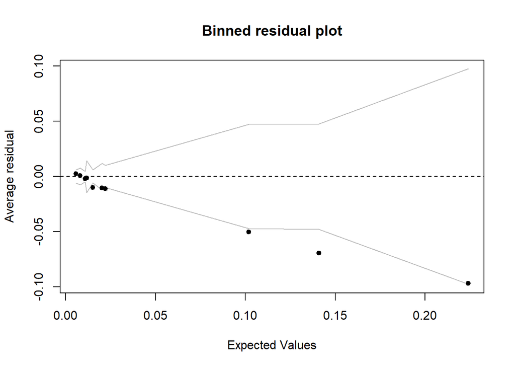

```r
binnedplot(fitted(red.gl),residuals(red.gl,type="response"))
```

```r
length(predict(red.gl))
```

```
## [1] 72
```

```r
length(dffits(red.gl))
```

```
## [1] 65
```

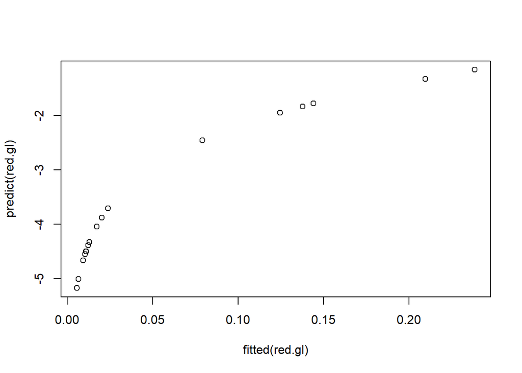

```r
plot(fitted(red.gl),predict(red.gl))
```

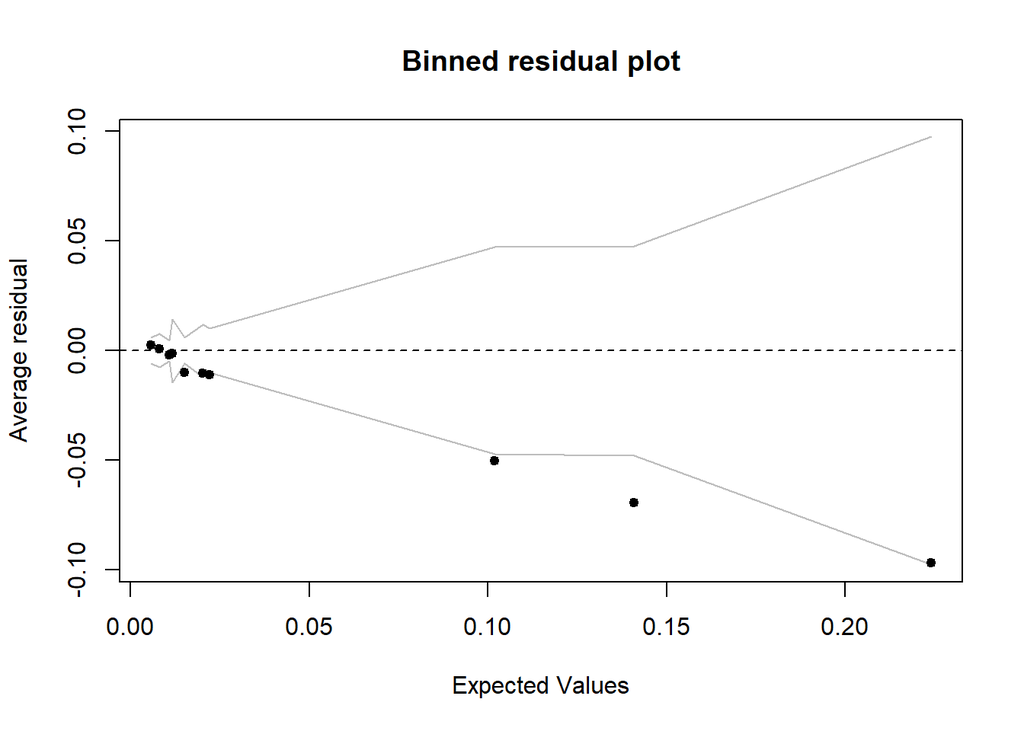

```r
#pearson residuals (Reduced GLM before AIC/BIC)

binnedplot(fitted(red.gl),residuals(red.gl,type="response"))
```

```r
pearson_vs_std<- cbind(rstandard(red.gl,type="pearson"), residuals(red.gl,type="pearson"),
residuals(red.gl,type="deviance"), rstandard(red.gl,type="deviance"))
colnames(pearson_vs_std) <-c("standardized","pearson","deviance","std. dev. residuals")
#head(pearson_vs_std)


summary(pearson_vs_std)
```

```
##   standardized        pearson            deviance
##  Min.   :-1.4927   Min.   :-1.31470   Min.   :-1.6239
##  1st Qu.:-0.7542   1st Qu.:-0.57847   1st Qu.:-0.7904
##  Median :-0.2075   Median :-0.15932   Median :-0.1946
##  Mean   :-0.1281   Mean   :-0.07553   Mean   :-0.1953
##  3rd Qu.: 0.3132   3rd Qu.: 0.27428   3rd Qu.: 0.2679
##  Max.   : 2.1650   Max.   : 2.07507   Max.   : 1.6605
##  std. dev. residuals
##  Min.   :-1.7526
##  1st Qu.:-0.8556
##  Median :-0.2803
##  Mean   :-0.2679
##  3rd Qu.: 0.3016
##  Max.   : 1.7325
```